# R Notebook

Ann Elisabeth Jacobsen og Heidi Marie Rolfsnes

## 1. What information does the file ddf_concepts.csv contain?

Filen ddf–concepts.csv ser ut til å inneholde en kort beskrivelse av datasettene som finnes i mappen *countries-etc-datapoints*.

## 2. What information does the file ddf—entities–geo—country.csv contain?

Beskrivelse av hvert enkelt land i datasettet slik som navn, forkortelse, verdensdel, geografiske koordinater, forkortelser etc.

## 3. What information does the the file ddg_entities–geo–un_sdg_region.csv contain?

Gir oss ulike regioner definert av FN. Ser at Australia og New Zealand er en egen region etter denne definisjonen.

## 4. What variables does the gapminder dataset from the gapminder package contain? To what continent are Australia and New Zealand assigned?

[output not shown]

## 5. Recreate the continent variable in gapminder with the new data?

Vi flytter Australia og New Zealand fra Asia til Osceania for å være på line med gapminder

```r
g_c <- read_csv("data/ddf--entities--geo--country.csv")
print(g_c)
```

```
## # A tibble: 273 × 22
##    country   g77_and_oecd_countries income_3groups income_groups   `is--country`
##    <chr>     <chr>                  <chr>          <chr>           <lgl>
##  1 abkh      others                 <NA>           <NA>            TRUE
##  2 abw       others                 high_income    high_income     TRUE
##  3 afg       g77                    low_income     low_income      TRUE
##  4 ago       g77                    middle_income  lower_middle_i… TRUE
##  5 aia       others                 <NA>           <NA>            TRUE
##  6 akr_a_dhe others                 <NA>           <NA>            TRUE
##  7 ala       others                 <NA>           <NA>            TRUE
##  8 alb       others                 middle_income  upper_middle_i… TRUE
##  9 and       others                 high_income    high_income     TRUE
## 10 ant       others                 <NA>           <NA>            TRUE
## # … with 263 more rows, and 17 more variables: iso3166_1_alpha2 <chr>,
## #   iso3166_1_alpha3 <chr>, iso3166_1_numeric <dbl>, iso3166_2 <chr>,
## #   landlocked <chr>, latitude <dbl>, longitude <dbl>,
## #   main_religion_2008 <chr>, name <chr>, un_sdg_ldc <chr>,
## #   un_sdg_region <chr>, un_state <lgl>, unhcr_region <chr>,
## #   unicef_region <chr>, unicode_region_subtag <chr>, world_4region <chr>,
## #   world_6region <chr>
```

```
Ser at Australia og New Zealand tilhører kontinentet Osceania i gapminder datasettet.
```

```r
spec(g_c)
g_c <- g_c %>%
   mutate(continent = case_when(
     world_4region == "asia" & un_sdg_region %in% c("un_australia_and_new_zealand","un_oceania_exc_australia_and_new_zealand") ~ "Oceania",
     world_4region == "asia" & !(un_sdg_region %in% c("un_australia_and_new_zealand", "un_oceania_exc_australia_and_new_zealand")) ~ "Asia",
     world_4region == "africa" ~ "Africa",
     world_4region == "americas" ~ "Americas",
     world_4region == "europe" ~ "Europe")
   ) %>%
   filter(!is.na(iso3166_1_alpha3))
```

## 6. How many countries are there now?

```r
length(unique(g_c$country))
```

```
## [1] 247
```

Nå er det 247 land.

## 6b) How many countries are there now in each continent?

```r
g_c %>%
  group_by(continent) %>%
  summarise(countries= length(unique(country)))
```

```
## # A tibble: 5 × 2
##   continent countries
##   <chr>         <int>
## 1 Africa           59
## 2 Americas         55
## 3 Asia             47
## 4 Europe           58
## 5 Oceania          28
```

## 7. Create the variable Life Expectancy (lifeExp) in g_c from the file

```r
lifeExp <- read_csv("data/countries-etc-datapoints/ddf--datapoints--life_expectancy_years--by--geo--time.csv",
col_types = cols(time = col_date(format = "%Y")))
lifeExp <- lifeExp %>%
  rename(year = time)
names(lifeExp)
```

```
## [1] "geo"                   "year"                  "life_expectancy_years"
```

```r
length(unique(lifeExp$geo))
```

```
## [1] 195
```

## 8. How many countries have information about lifeExp?

```
195 land har informasjon om levetid.
```

```r
length(unique(lifeExp$geo))
```

```
## [1] 195
```

## 9. reduce g_c to the variables: country, name, iso3166_1_alpha3,un_sdg_region, world_4region, continent, world_6region

```r
g_c <- g_c %>%
  select(country, name, iso3166_1_alpha3, un_sdg_region, world_4region, continent, world_6region) %>%
  left_join(lifeExp, by = c("country" = "geo"))
```

```r
names(g_c)
```

```
## [1] "country"               "name"                  "iso3166_1_alpha3"
## [4] "un_sdg_region"         "world_4region"         "continent"
## [7] "world_6region"         "year"                  "life_expectancy_years"
```

## 10. What is the first observation of lifeExp for the different countries?

```r
    g_c_min <- g_c %>%
      group_by(country) %>%
      summarise(min_year = min(lifeExp$year))
      table(g_c_min$min_year)
```

```
##
## 1800-01-01
##        247
```

```r
g_c_min <- g_c_min %>%
  left_join(g_c,
            by = "country") %>%
  filter(min_year == "1950-01-01")
tibble(country = unique(g_c_min$name))
```

```
## # A tibble: 0 × 1
## # … with 1 variable: country <chr>
```

## 12. Read in the total_population and join with g_c

```r
pop <- read_csv("data/countries-etc-datapoints/ddf--datapoints--population_total--by--geo--time.csv",
                 col_types = cols(time = col_date(format = "%Y")))
```

```r
g_c <- g_c %>%
  left_join(pop, by = c("country" = "geo", "year" ="time"))
```

## 13. Read in the gdp_percapita_us_inflation_adjusted and call it “gdp_pc” Rename life_expectancy_years to lifeExp, population_total to pop and gdppercapita_us_inflation_adjusted to gdpPercap

````
```r
gdp_pc <- read_csv("data/countries-etc-datapoints/ddf--datapoints--gdppercapita_us_inflation_adjusted--by--geo--time.csv",
 col_types = cols(time = col_date(format = "%Y")))
```
````

```r
 g_c <- g_c %>%
      left_join(gdp_pc, by = c("country" = "geo", "year" = "time"))
rm(gdp_pc)
```

````
```r
g_c <- g_c %>%
  rename(lifeExp = "life_expectancy_years") %>%
  rename(pop = "population_total") %>%
  rename(gdpPercap = "gdppercapita_us_inflation_adjusted")

# %>%
  # g_c flyter alt i pipen og vil være første argument til names
  #names(g_c)
  #names()
```
````

```r
# denne for å se variabel navnene. Farlig i pipe hvor en tilornder som ovenfor. Ender opp med at g_c
# bare innholder variabelnavnene og ingenting annet
names(g_c)
```

```
##  [1] "country"          "name"             "iso3166_1_alpha3" "un_sdg_region"
##  [5] "world_4region"    "continent"        "world_6region"    "year"
##  [9] "lifeExp"          "pop"              "gdpPercap"
```

## 14. As in gapminder use data from every 5th year, but include 2019 at the end.

```r
t1 <- paste(c(seq(1800,2015, by = 5), 2019), "01-01", sep = "-") %>%
  parse_date(format = "%Y-%m-%d")

g_c_5 <- g_c %>%
  filter(year %in% t1) %>%
  select(country, name, continent, year, lifeExp, pop, gdpPercap)

dim(g_c_5)
```

```
## [1] 8505    7
```

```r
g_c_gdpprc <- g_c_5 %>%
  group_by(gdpPercap) %>%
  summarise(min_year = min(year))

table(g_c_gdpprc$min_year)
```

```
##
## 1800-01-01 1960-01-01 1965-01-01 1970-01-01 1975-01-01 1980-01-01 1985-01-01
##          1         85         92        107        111        132        141
## 1990-01-01 1995-01-01 2000-01-01 2005-01-01 2010-01-01 2015-01-01 2019-01-01
##        160        176        184        187        188        190        188
```

## 15. Make a vector containing the names of the countries with the longest time series for gdp per capita

```r
g_c <- g_c %>%
  filter(!is.na(gdpPercap)) %>%
  group_by(name) %>%
    summarise(nr = n()) %>%
    arrange(name)

print(g_c)
```

```
## # A tibble: 190 × 2
##    name                   nr
##    <chr>               <int>
##  1 Afghanistan            19
##  2 Albania                41
##  3 Algeria                61
##  4 Andorra                50
##  5 Angola                 41
##  6 Antigua and Barbuda    44
##  7 Argentina              61
##  8 Armenia                31
##  9 Australia              61
## 10 Austria                61
## # … with 180 more rows
```

## 16. make a subset of gapminder, my_gapminder_1960, which include countries with data from 1960-2019. How many countries are now in the dataset? How many countries from each continent? how many NAs are there in my_gapminder_1960

```r
c_m_y_60 <- g_c_5 %>%
      filter(!is.na(gdpPercap)) %>%
      # name trengs ikke her i group_by men triks for å få name variabelen med i output
      group_by(country, name) %>%
      summarise(min_year = min(year))
head(c_m_y_60)
```

```
## # A tibble: 6 × 3
## # Groups:   country [6]
##   country name                 min_year
##   <chr>   <chr>                <date>
## 1 afg     Afghanistan          2005-01-01
## 2 ago     Angola               1980-01-01
## 3 alb     Albania              1980-01-01
## 4 and     Andorra              1970-01-01
## 5 are     United Arab Emirates 1975-01-01
## 6 arg     Argentina            1960-01-01
```

```r
# Plukker ut det minste min_year (første år vi har data for)
fy <- c_m_y_60 %>%
  mutate(
    aar = as.numeric(lubridate::year(min_year))
  )

first_year <- paste(min(fy$aar), "01", "01", sep = "-")
```

```r
#land med data fra 1960
country_1960 <- c_m_y_60 %>%
  filter(min_year == first_year) %>%
  select(country) %>%
  # for å få country ut av tibblene
  pull()
# nå har vi en vector med 85 land forkortelser for dem som har data fra 1960
```

```r
dim(c_m_y_60)
```

```
## [1] 190   3
```

```r
#c_m_y_60 <- my_gapminder_60$country[my_gapminder_60$min_year == "1960-01-01"]

my_gapminder_60 <- g_c_5 %>%
  filter(!is.na(gdpPercap)) %>%
  filter(country %in% country_1960)


my_gapminder_60
```

```
## # A tibble: 1,105 × 7
##    country name      continent year       lifeExp      pop gdpPercap
##    <chr>   <chr>     <chr>     <date>       <dbl>    <dbl>     <dbl>
##  1 arg     Argentina Americas  1960-01-01    65.3 20481781     7363.
##  2 arg     Argentina Americas  1965-01-01    66.1 22159644     8202.
##  3 arg     Argentina Americas  1970-01-01    66.1 23880564     9243.
##  4 arg     Argentina Americas  1975-01-01    68.0 25865775     9940.
##  5 arg     Argentina Americas  1980-01-01    70.2 27896532    10318.
##  6 arg     Argentina Americas  1985-01-01    71.7 30216284     9009.
##  7 arg     Argentina Americas  1990-01-01    72.5 32618648     8149.
##  8 arg     Argentina Americas  1995-01-01    73.4 34828168    10003.
##  9 arg     Argentina Americas  2000-01-01    74.2 36870796    10731.
## 10 arg     Argentina Americas  2005-01-01    75.3 38892924    11192.
## # … with 1,095 more rows
```

```r
dim(my_gapminder_60)
```

```
## [1] 1105    7
```

```r
length(unique(my_gapminder_60$country))
```

```
## [1] 85
```

```r
# kommentert ut for å få dokumentet til å kjøre
#num_NA <- sum(is.na(c_m_y_60$gdpPercap))
```

```r
#paste("Number of NAs in g_c_1960 is", dim(num_NA)[1], sep = " ")
```

```r
my_gapminder_60 %>%
  distinct(country, continent) %>%
  group_by(continent) %>%
  count() %>%
  kable()
```

| continent | n |
| --- | --- |
| Africa | 29 |
| Americas | 24 |
| Asia | 14 |
| Europe | 15 |
| Oceania | 3 |

## 17. Use ggplot() and let x be gdpPercap, y be lifeExp and size the population. Make a plot for each of the year 1960, 1980, 2000 and 2019.

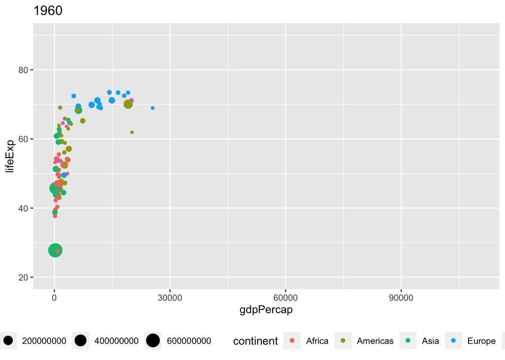

```r
    my_gapminder_60 %>%
      filter(year <= "1960-01-01") %>%
      ggplot(mapping = aes(x = gdpPercap, y = lifeExp, size = pop, colour = continent)) +
      geom_point() +
      coord_cartesian(ylim = c(20, 90), xlim = c(0,110000)) +
       ggtitle("1960") +
      theme(legend.position = "bottom")
```

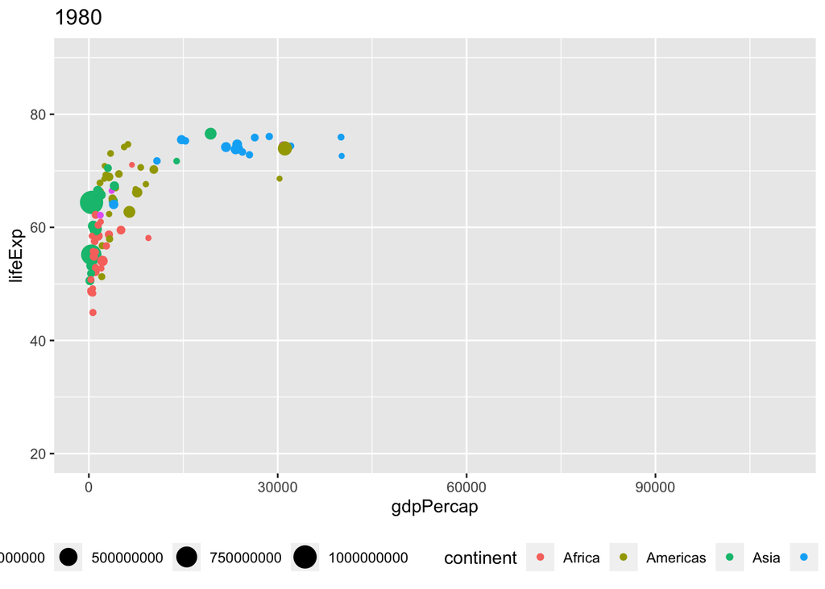

```r
    my_gapminder_60 %>%
      filter(year == "1980-01-01") %>%
      ggplot(mapping = aes(x = gdpPercap, y = lifeExp, size = pop, colour = continent)) +
      geom_point() +
      coord_cartesian(ylim = c(20, 90), xlim = c(0,110000)) +
       ggtitle("1980") +
      theme(legend.position = "bottom")
```

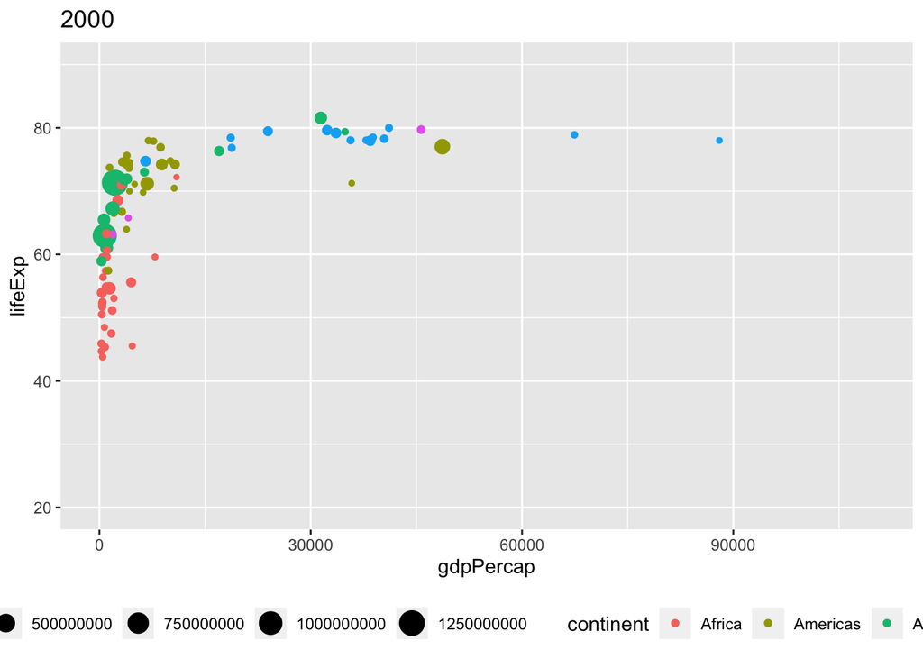

```r
     my_gapminder_60 %>%
      filter(year == "2000-01-01") %>%
      ggplot(mapping = aes(x = gdpPercap, y = lifeExp, size = pop, colour = continent)) +
      geom_point() +
      coord_cartesian(ylim = c(20, 90), xlim = c(0,110000)) +
       ggtitle("2000") +
      theme(legend.position = "bottom")
```

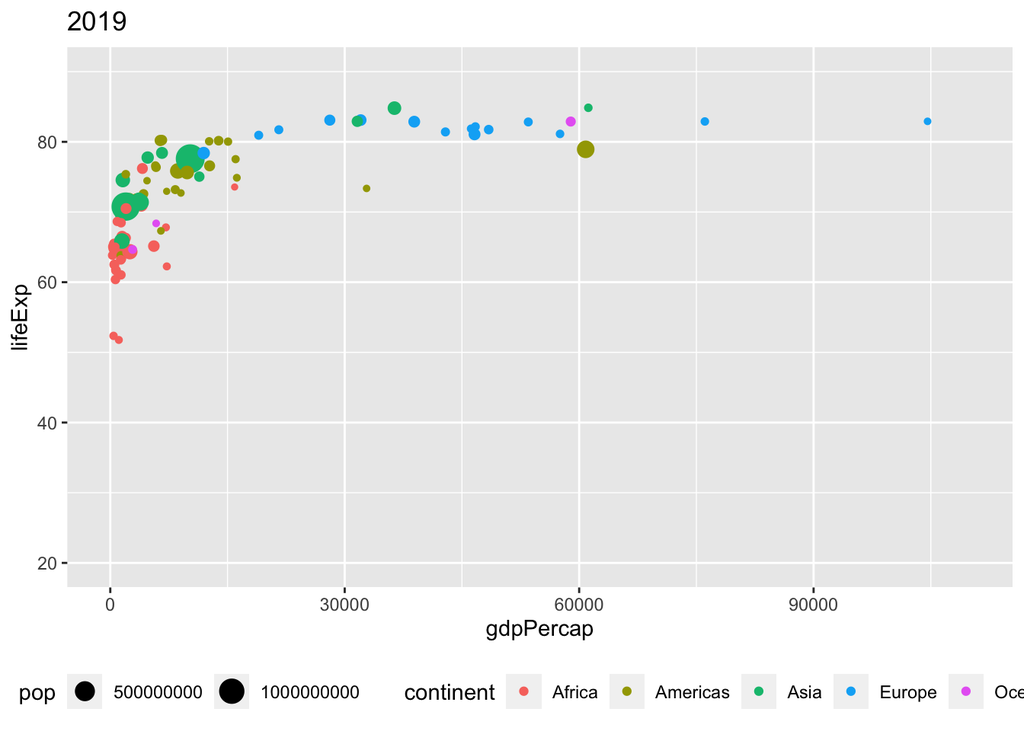

```r
     my_gapminder_60 %>%
      filter(year == "2019-01-01") %>%
      ggplot(mapping = aes(x = gdpPercap, y = lifeExp, size = pop, colour = continent)) +
      geom_point() +
      coord_cartesian(ylim = c(20, 90), xlim = c(0,110000)) +
       ggtitle("2019") +
      theme(legend.position = "bottom")
```

## 18. Do the same four plots as above, but now use the log transform of gdpPercap, i.e mapping.

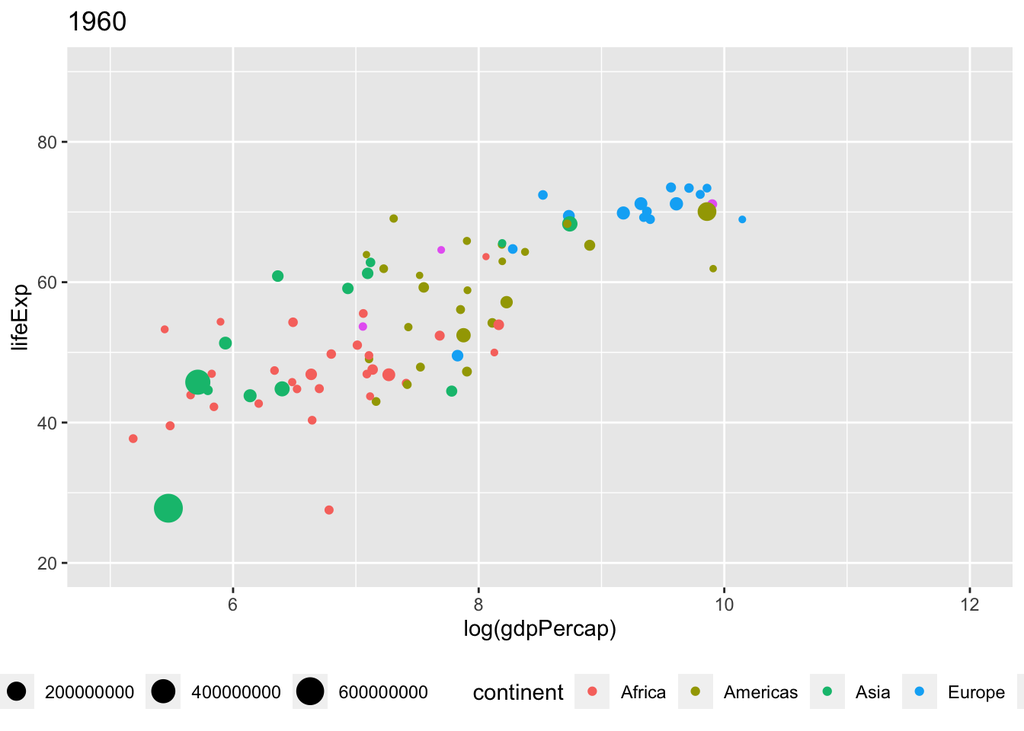

```r
my_gapminder_60 %>%
  filter(year == "1960-01-01") %>%
  ggplot(mapping = aes(x = log(gdpPercap), y = lifeExp, size = pop, colour = continent)) +
  # coord_cartesian() helt greit, men disse to er kanskje lettere å huske
  xlim(5, 12) +
  ylim(20, 90) +
  geom_point() +
  # coord_cartesian(ylim = c(20, 90), xlim = c(5, 11)) +
  ggtitle("1960") +
  theme(legend.position = "bottom")
```

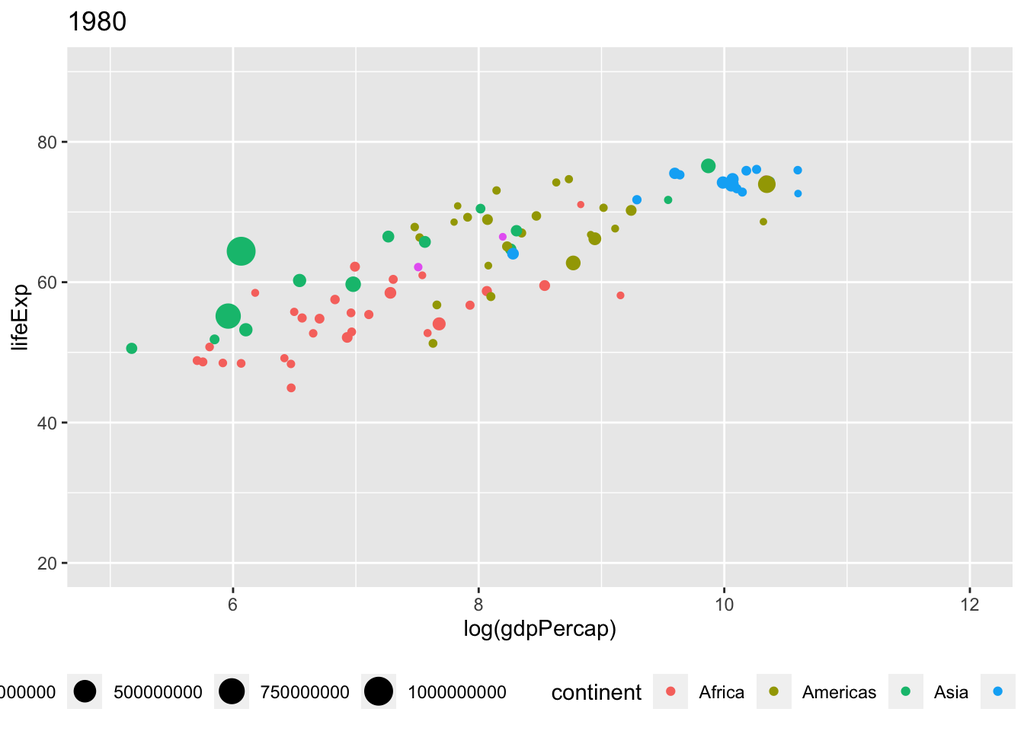

```r
my_gapminder_60 %>%
  filter(year == "1980-01-01") %>%
  ggplot(mapping = aes(x = log(gdpPercap), y = lifeExp, size = pop, colour = continent)) +
  # coord_cartesian() helt greit, men disse to er kanskje lettere å huske
  xlim(5, 12) +
  ylim(20, 90) +
  geom_point() +
  # coord_cartesian(ylim = c(20, 90), xlim = c(5, 11)) +
  ggtitle("1980") +
  theme(legend.position = "bottom")
```

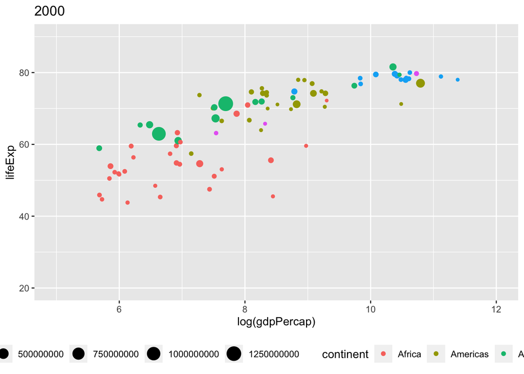

```r
my_gapminder_60 %>%
  filter(year == "2000-01-01") %>%
  ggplot(mapping = aes(x = log(gdpPercap), y = lifeExp, size = pop, colour = continent)) +
  # coord_cartesian() helt greit, men disse to er kanskje lettere å huske
  xlim(5, 12) +
  ylim(20, 90) +
  geom_point() +
  # coord_cartesian(ylim = c(20, 90), xlim = c(5, 11)) +
  ggtitle("2000") +
  theme(legend.position = "bottom")
```

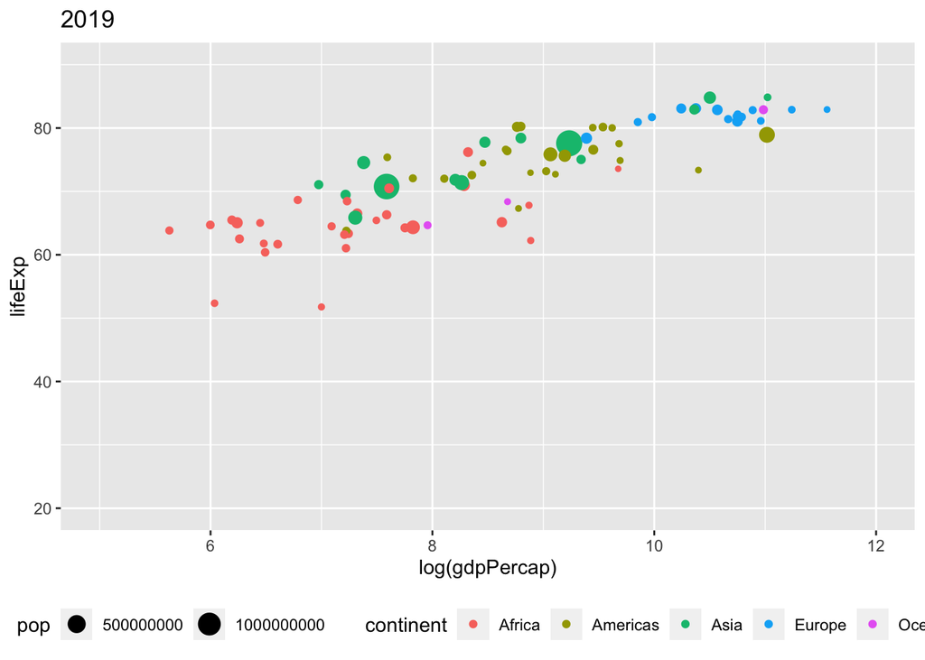

```r
my_gapminder_60 %>%
  filter(year == "2019-01-01") %>%
  ggplot(mapping = aes(x = log(gdpPercap), y = lifeExp, size = pop, colour = continent)) +
  # coord_cartesian() helt greit, men disse to er kanskje lettere å huske
  xlim(5, 12) +
  ylim(20, 90) +
  geom_point() +
  # coord_cartesian(ylim = c(20, 90), xlim = c(5, 11)) +
  ggtitle("2019") +
  theme(legend.position = "bottom")
```

## 19. How will you characterise the development the 59 years from 1960 to 2019?

```
Levetiden har økt betraktelig fra 1960 til 2019.
```

## 20. Save your datafiles as my_gapminder.csv and my_gapminder_red.csv

```r
write.table(g_c_5, file="my_gapminder.csv", sep = ",")
#write.table(g_c_1960, file="my_gapminder_red.csv", sep = ",")
# try to use tidyverse functions
write_csv(my_gapminder_60, file = "my_gapminder_60.csv")
```